# DS Minor: Lab 01 – Networks Intro

### “Все связано”

- взаимосвязи между людьми (профессиональные, дружеские, семейные,..)
- связи между организациями, союзами, странами…
- связи между предметами (компьютеры, книги, фильмы…)
- связи между понятиями
- …

Два основных понятия – вершины (узлы, vertices, nodes) и связи (дуги, ребра, links, edges).

- что может являться вершинами и связями в списке выше?
- приведите свои примеры

Немного примеров

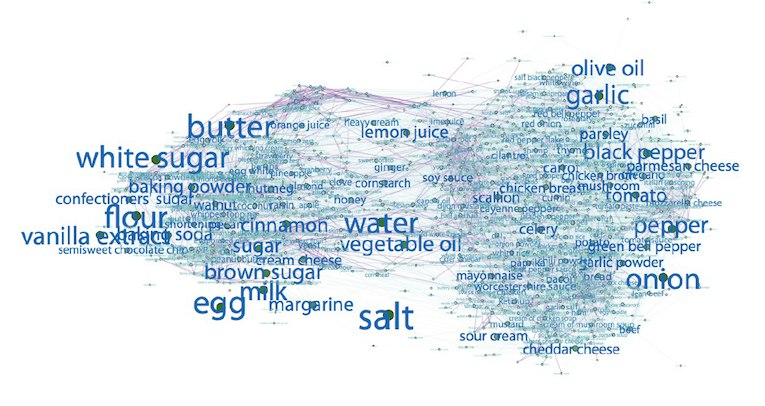

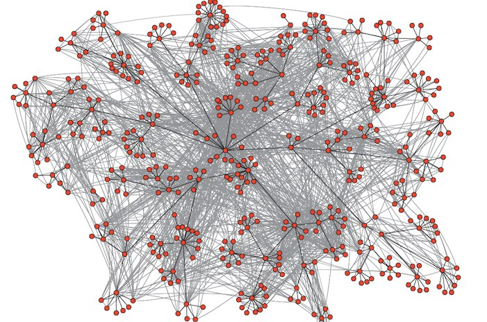

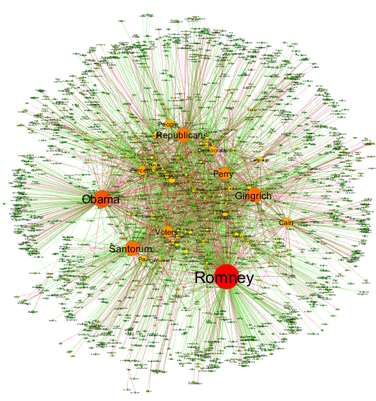

US election news coverage

[figure not shown]

The Political Blogosphere and the 2004 U.S. Election: Divided They Blog

### Формализация сетей – графы

#### Термины и понятия

- граф (graph)
- вершина, узел (node)
- ребро, связь (edge)
- ориентированные (направленные) / неориентированные графы (directed / undirected graph)
- список ребер (edgelist)
- матрица смежности (adjacency matrix)

#### Инструмент

Мы будем работать с пакетом `igraph` для создания и работы с направленными и ненаправленными графами (http://igraph.org/r/)

```r
library(igraph)
```

#### Небольшие примеры для обсуждения понятий

**Граф** – способ формально описать взаимосвязи между набором элементов (**вершин, nodes**). **Ребро (edge)** – связь между элементами, представляется как пара вершин (начало-конец)

**Ориентированный граф** – несимметричная связь, направление важно. **Неориентированный граф** – симметричная связь (*A* и *B* связаны).

- какие графы являются ориентированными? Неориентированными?
- сколько вершин в графах? Ребер?

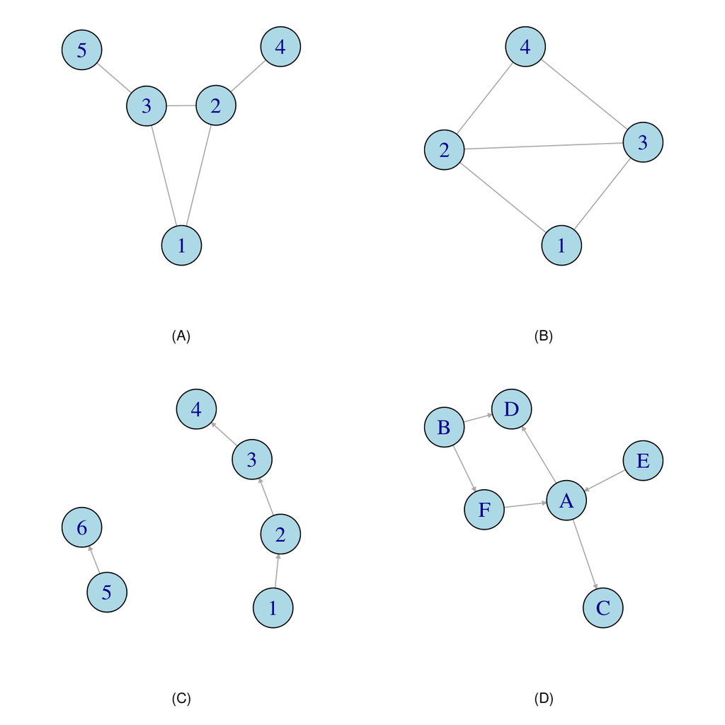

### Создание графа

Граф состоит из набора вершин и набора ребер. Один из способов его задания – определить список ребер **edgelist**, т.е. список пар связанных вершин.

```r
exampleGr <- make_graph(c("Mary","Fred",
                          "Mary","Lee",
                          "Fred","Lee",
                          "Elisa","Mary",
                          "Fred","Sam",
                          "Sam","Mary"), directed = F)
```

Результат вызова функции `print()` – описание созданного объекта

```r
exampleGr
```

```
## IGRAPH 5bcc37e UN-- 5 6 --
## + attr: name (v/c)
## + edges from 5bcc37e (vertex names):
## [1] Mary--Fred  Mary--Lee   Fred--Lee   Mary--Elisa Fred--Sam   Mary--Sam
```

Нарисовать граф можно с помощью функции `plot()`:

```r
dev.off()
```

```r
plot(exampleGr)
```

[output not shown]

#### Загрузка графа

Мы рассмотрели пример создания графа вручную, но в большинстве случаев мы будем загружать их из файлов некоторого формата. `igraph` позволяет использовать многие форматы файлов.

##### Список ребер

`graph_from_data_frame` создает граф igraph из таблицы данных (data frame), первые два столбца которого рассматриваются как список ребер (начало - конец), остальные – как дополнительные свойства ребер.

Рассмотрим искусственную социальную сеть *Krackhardt’s kite*.

```r
library(readr)
edgelist <- read_csv("~/shared/minor2_2018/2-tm-net/lab01-netIntro/kite.csv")
head(edgelist)
```

```
## # A tibble: 6 x 2
##   V1    V2
##   <chr> <chr>
## 1 A     B
## 2 A     C
## 3 A     D
## 4 A     F
## 5 B     D
## 6 B     E
```

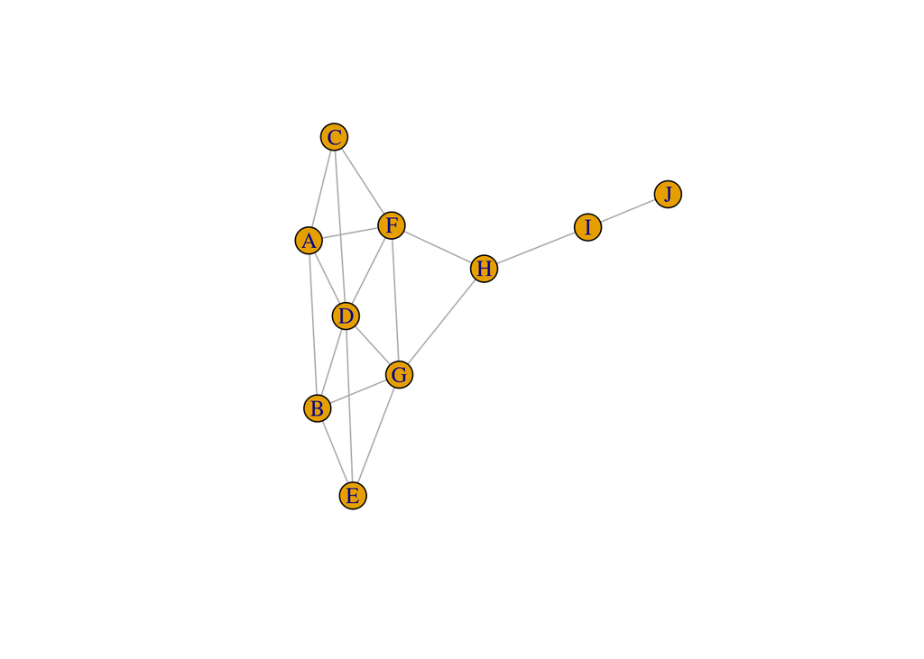

```r
kite <- graph_from_data_frame(edgelist, directed = FALSE) #обязательно загляните в справку и посмотрите как достать из igraph объекта data frame

plot(kite)
```

##### Матрица смежности (Adjacency matrix)

Еще одно представление графа – **матрица смежности** (adjacency matrix), т.е. матрица |V|x|V|, где |V| – число вершин, а элемент в i-ой строке и j-ом столбце равен 1, если есть связь между вершиной i и вершиной j, и 0 в противном случае.

Рассмотрим отношения между семьями Флоренции (Renaissance Florentine families collected by John Padgett from historical documents). Связь – брачные договоры.

```r
adjFlorence <- read_csv("~/shared/minor2_2018/2-tm-net/lab01-netIntro/florentineFamily.csv")
rownames(adjFlorence) <- names(adjFlorence)
adjFlorence <- as.matrix.data.frame(adjFlorence)
```

Матрица смежности

```r
# View(adjFlorence)
pander::pandoc.table(adjFlorence, split.tables = Inf)
```

|  | Acciaiuol | Albizzi | Barbadori | Bischeri | Castellan | Ginori | Guadagni | Lambertes | Medici | Pazzi | Peruzzi | Pucci | Ridolfi | Salviati | Strozzi | Tornabuon |
| --- | --- | --- | --- | --- | --- | --- | --- | --- | --- | --- | --- | --- | --- | --- | --- | --- |
| **Acciaiuol** | 0 | 0 | 0 | 0 | 0 | 0 | 0 | 0 | 1 | 0 | 0 | 0 | 0 | 0 | 0 | 0 |
| **Albizzi** | 0 | 0 | 0 | 0 | 0 | 1 | 1 | 0 | 1 | 0 | 0 | 0 | 0 | 0 | 0 | 0 |
| **Barbadori** | 0 | 0 | 0 | 0 | 1 | 0 | 0 | 0 | 1 | 0 | 0 | 0 | 0 | 0 | 0 | 0 |
| **Bischeri** | 0 | 0 | 0 | 0 | 0 | 0 | 1 | 0 | 0 | 0 | 1 | 0 | 0 | 0 | 1 | 0 |
| **Castellan** | 0 | 0 | 1 | 0 | 0 | 0 | 0 | 0 | 0 | 0 | 1 | 0 | 0 | 0 | 1 | 0 |
| **Ginori** | 0 | 1 | 0 | 0 | 0 | 0 | 0 | 0 | 0 | 0 | 0 | 0 | 0 | 0 | 0 | 0 |
| **Guadagni** | 0 | 1 | 0 | 1 | 0 | 0 | 0 | 1 | 0 | 0 | 0 | 0 | 0 | 0 | 0 | 1 |
| **Lambertes** | 0 | 0 | 0 | 0 | 0 | 0 | 1 | 0 | 0 | 0 | 0 | 0 | 0 | 0 | 0 | 0 |
| **Medici** | 1 | 1 | 1 | 0 | 0 | 0 | 0 | 0 | 0 | 0 | 0 | 0 | 1 | 1 | 0 | 1 |
| **Pazzi** | 0 | 0 | 0 | 0 | 0 | 0 | 0 | 0 | 0 | 0 | 0 | 0 | 0 | 1 | 0 | 0 |
| **Peruzzi** | 0 | 0 | 0 | 1 | 1 | 0 | 0 | 0 | 0 | 0 | 0 | 0 | 0 | 0 | 1 | 0 |
| **Pucci** | 0 | 0 | 0 | 0 | 0 | 0 | 0 | 0 | 0 | 0 | 0 | 0 | 0 | 0 | 0 | 0 |
| **Ridolfi** | 0 | 0 | 0 | 0 | 0 | 0 | 0 | 0 | 1 | 0 | 0 | 0 | 0 | 0 | 1 | 1 |
| **Salviati** | 0 | 0 | 0 | 0 | 0 | 0 | 0 | 0 | 1 | 1 | 0 | 0 | 0 | 0 | 0 | 0 |
| **Strozzi** | 0 | 0 | 0 | 1 | 1 | 0 | 0 | 0 | 0 | 0 | 1 | 0 | 1 | 0 | 0 | 0 |
| **Tornabuon** | 0 | 0 | 0 | 0 | 0 | 0 | 1 | 0 | 1 | 0 | 0 | 0 | 1 | 0 | 0 | 0 |

Создание графа по матрице (`graph_from_adjacency_matrix`)

```r
florentine <- graph_from_adjacency_matrix(adjmatrix = adjFlorence, mode = "undirected")
```

Функции `V()` и `E()` выдают список вершин и ребер соответственно.

```r
V(florentine)
```

```
## + 16/16 vertices, named, from 5f660c8:
##  [1] Acciaiuol Albizzi   Barbadori Bischeri  Castellan Ginori    Guadagni
##  [8] Lambertes Medici    Pazzi     Peruzzi   Pucci     Ridolfi   Salviati
## [15] Strozzi   Tornabuon
```

```r
E(florentine)
```

```
## + 20/20 edges from 5f660c8 (vertex names):
##  [1] Acciaiuol--Medici    Albizzi  --Ginori    Albizzi  --Guadagni
##  [4] Albizzi  --Medici    Barbadori--Castellan Barbadori--Medici
##  [7] Bischeri --Guadagni  Bischeri --Peruzzi   Bischeri --Strozzi
## [10] Castellan--Peruzzi   Castellan--Strozzi   Guadagni --Lambertes
## [13] Guadagni --Tornabuon Medici   --Ridolfi   Medici   --Salviati
## [16] Medici   --Tornabuon Pazzi    --Salviati  Peruzzi  --Strozzi
## [19] Ridolfi  --Strozzi   Ridolfi  --Tornabuon
```

Для получения числа вершин и ребер в графе можно использовать функции `vcount()` и `ecount()`

```r
vcount(florentine)
```

```
## [1] 16
```

```r
ecount(florentine)
```

```
## [1] 20
```

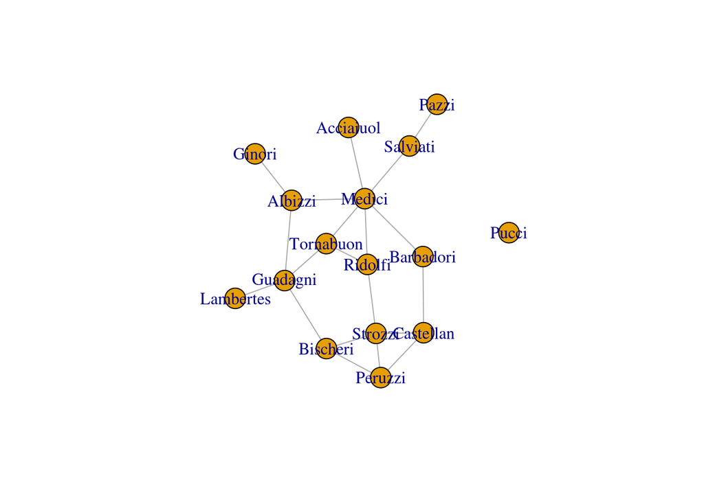

```r
plot(florentine)
```

#### Другие форматы файлов

`igraph` позволяет читать и файлы других форматов, например, файл *Pajek*. Подробности и другие форматы в `?read.graph()`

### Рисование графа

В пакете `igraph` много параметров для визуализации графов. Более подробно можно посмотреть в `?igraph.plotting`.

Подробнее мы будем говорить о визуализации следующий раз, но можно менять цвета, размеры, подписи, фон и т.д., чтобы получить именно тот вид графа, что нужен. Существует два способа определения этих параметров.

Первый – указать их в функции `plot`:

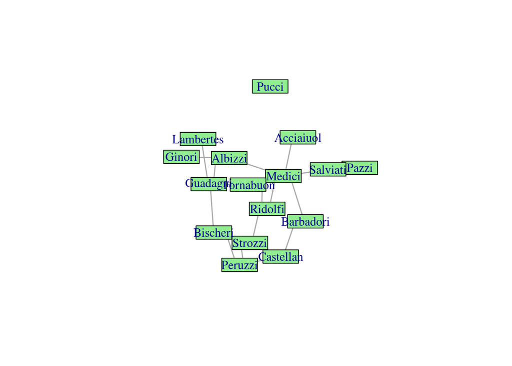

```r
plot(florentine,
     vertex.color = "lightgreen",
     vertex.size = 40,
     vertex.shape = "rectangle",
     edge.width = 1.5)
```

Второй способ – задать нужные значения как свойства вершин или ребер.

```r
#проверим до
V(florentine)$color
```

```r
V(florentine)$color = "lightblue"

#проверим после
V(florentine)$color
```

```
##  [1] "lightblue" "lightblue" "lightblue" "lightblue" "lightblue"
##  [6] "lightblue" "lightblue" "lightblue" "lightblue" "lightblue"
## [11] "lightblue" "lightblue" "lightblue" "lightblue" "lightblue"
## [16] "lightblue"
```

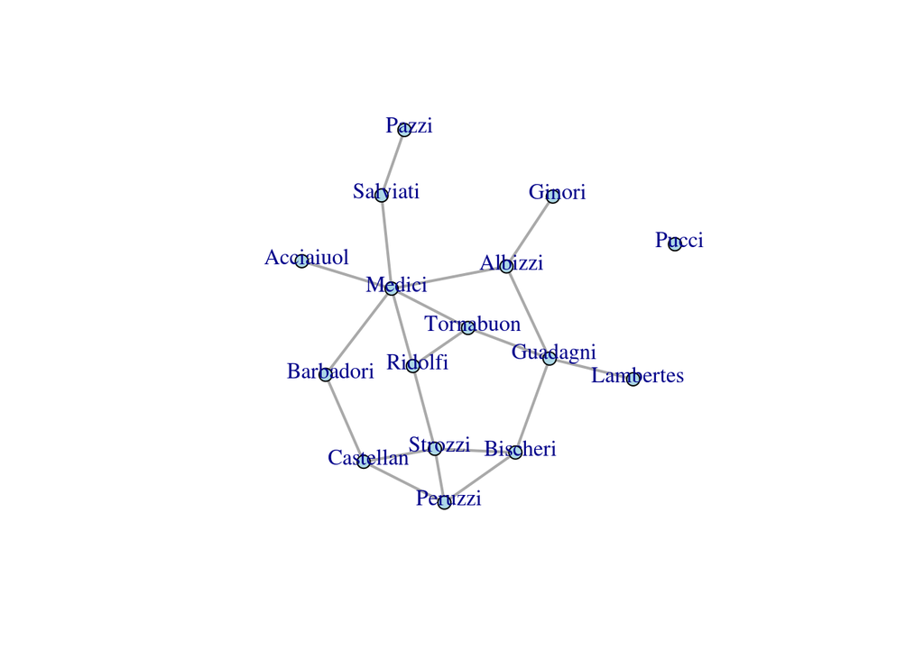

```r
V(florentine)$size = 7
V(florentine)$label.dist = 0.5 # labels outside the circles
E(florentine)$width = 2
plot(florentine)
```

Еще один параметр визуализации – укладка (layout)

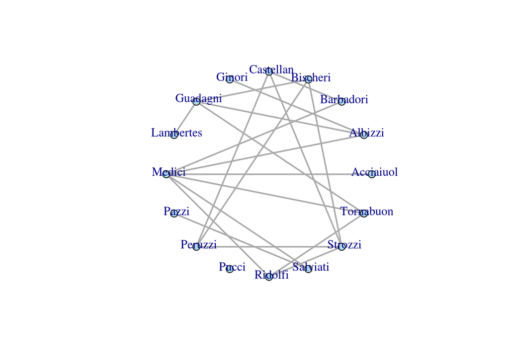

```r
plot(florentine, layout = layout.circle)
```

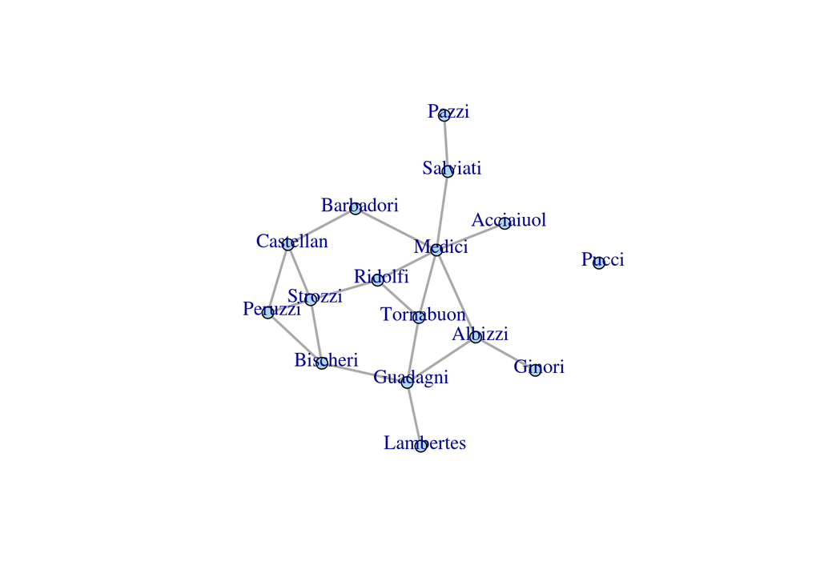

```r
plot(florentine, layout = layout.fruchterman.reingold)
```

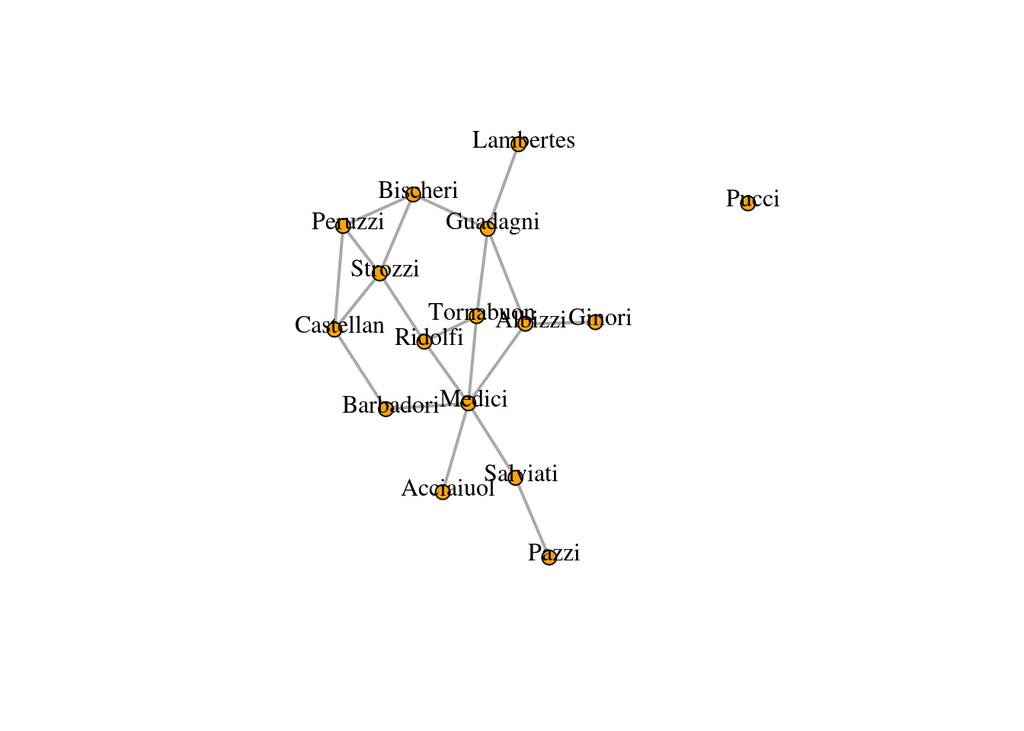

```r
plot(florentine, layout = layout.kamada.kawai,
     vertex.color = "orange",
     vertex.label.color = "black")
```